# Machine learning assignment

Anh Bui

May 21, 2016

## Summary

The Weight Lifting Excercise (WLE) Dataset (http://groupware.les.inf.puc-rio.br/har) is analyzed with various machine learning tools.

The analysis indicates that the random forest model can provide the most accurate fitting for the data.

The prediction of the *testing* dataset is given at the end of the report.

## Introduction

The Weight Lifting Excercise (WLE) Dataset is given at http://groupware.les.inf.puc-rio.br/har which comprises the data measured by the sensors located on the body and dumbell as shown in the figure below. The dataset was obtained for 6 participants who were asked to perform barbell lifts correctly and incorrectly in 5 different ways: exactly according to the specification (Class A), throwing the elbows to the front (Class B), lifting the dumbbell only halfway (Class C), lowering the dumbbell only halfway (Class D) and throwing the hips to the front (Class E). Class A corresponds to the specified execution of the exercise, while the other 4 classes correspond to common mistakes.

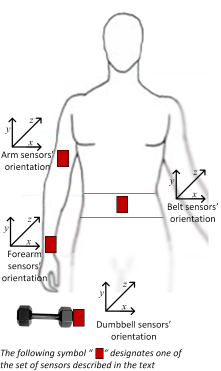

The goal of this analysis is to build a model that can predict the manner or the way in which people did the excercise (the class variable) based on the sensor data.

## Classification tree model

A classification tree model is going to be built which classifies the exercise class based on the sensor data.

The data are imported as follows

```r
training <- read.csv("pml-training.csv",na.strings=c("NA","#DIV/0!",""))
testing <- read.csv("pml-testing.csv",na.strings=c("NA","#DIV/0!",""))
```

Columns that contains NA, blanks and unnecessary information, e.g. “X”, “user_name”, “*timestamps, etc, are removed

```r
nonNACols <- colSums(is.na(training)) == 0
training <- training[,nonNACols]
testing <- testing[,nonNACols]
nonEmpCols <- colSums(training == "") == 0
training <- training[,nonEmpCols]
testing <- testing[,nonEmpCols]
training <- training[,-c(1:7)]
testing <- testing[,-c(1:7)]
dim(training)
```

```
## [1] 19622    53
```

```r
dim(testing)
```

```
## [1] 20 53
```

The *nearZeroVar* function is used to find the columns for which the variances are equal to or near zero

```r
library(caret)
nearZeroVar(training)
```

```
## integer(0)
```

The above check indicates that there is no such column (or variable).

The training set is splitted into *mTraining* and *mCrossVal* datasets as follows

```r
inTrain <- createDataPartition(y=training$classe,p=0.6,list=FALSE)
mTraining <- training[inTrain,]
mCrossVal <- training[-inTrain,]
```

A classification tree model is constructed as follows

```r
library(rpart)
set.seed(1234)
rpModel <- train(classe ~ .,method="rpart",data=mTraining)
```

The classification tree is plotted with the *fancyRpartPlot* function:

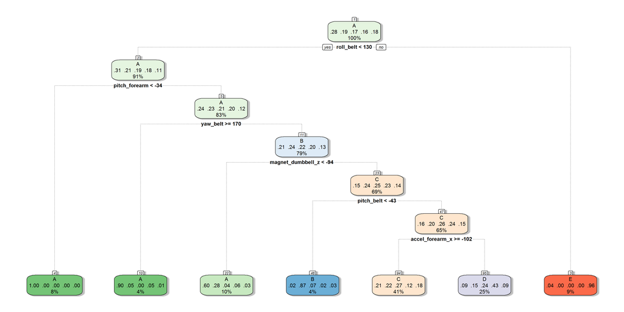

```r
library(rattle)
fancyRpartPlot(rpModel$finalModel,sub="")
```

The *rpart* model is used to predict the *mCrossVal* dataset as follows

```r
rpPred <- predict(rpModel,mCrossVal)
```

The accuracy of this model is found to be

```r
confusionMatrix(rpPred,mCrossVal$classe)$overall['Accuracy']
```

```
##  Accuracy
## 0.5043334
```

which seems to be low.

It is intersting to note that using the independent *rpart* fitting instead of *train* results in a different classification tree and a higher accuracy as shown below.

```r
set.seed(1234)
rpModel <- rpart(classe ~ .,data=mTraining)
#fancyRpartPlot(rpModel,sub="")
rpPred <- predict(rpModel,mCrossVal,type="class")
confusionMatrix(rpPred,mCrossVal$classe)$overall['Accuracy']
```

```
##  Accuracy
## 0.7211318
```

## Random forest (rf) model

A random forest is constructed as follows

```r
library(randomForest)
set.seed(1234)
rfModel <- randomForest(classe~.,data=mTraining)
print(rfModel)
```

```
##
## Call:
##  randomForest(formula = classe ~ ., data = mTraining)
##                Type of random forest: classification
##                      Number of trees: 500
## No. of variables tried at each split: 7
##
##         OOB estimate of  error rate: 0.68%
## Confusion matrix:
##      A    B    C    D    E class.error
## A 3339    8    0    0    1 0.002688172
## B   14 2258    7    0    0 0.009214568
## C    0   17 2033    4    0 0.010223953
## D    0    0   20 1907    3 0.011917098
## E    0    0    2    4 2159 0.002771363
```

The class errors versus the tree number is plotted as

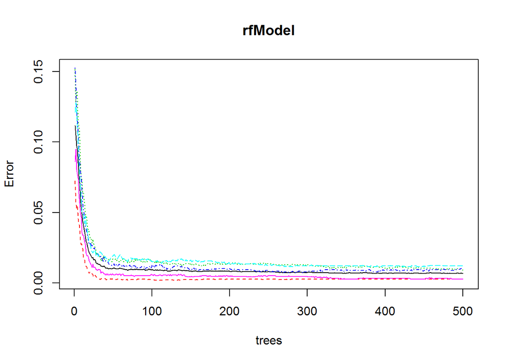

```r
plot(rfModel)
```

```r
library(randomForest)
set.seed(1234)
rfModel <- randomForest(classe~.,data=mTraining,ntree=90)
print(rfModel)
```

```
##
## Call:
##  randomForest(formula = classe ~ ., data = mTraining, ntree = 90)
##                Type of random forest: classification
##                      Number of trees: 90
## No. of variables tried at each split: 7
##
##         OOB estimate of  error rate: 0.96%
## Confusion matrix:
##      A    B    C    D    E class.error
## A 3339    8    0    0    1 0.002688172
## B   29 2240   10    0    0 0.017112769
## C    1   18 2031    4    0 0.011197663
## D    0    0   28 1899    3 0.016062176
## E    0    0    3    8 2154 0.005080831
```

The variable importance can be analyzed using the *varImpPlot* function

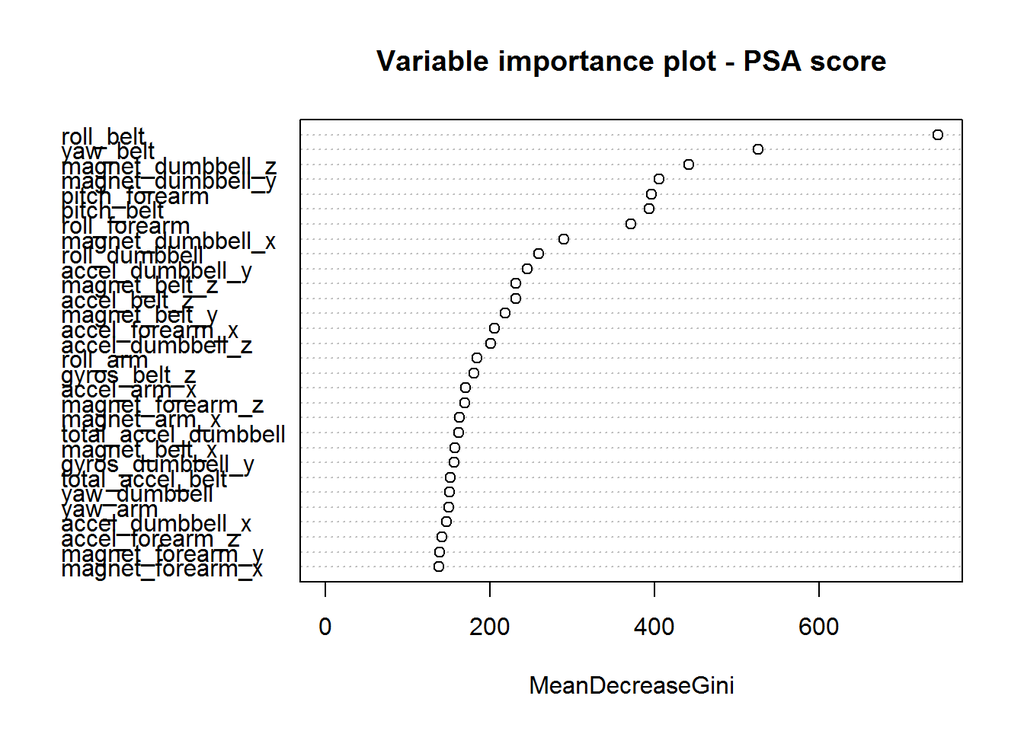

```r
varImpPlot(rfModel,main="Variable importance plot - PSA score")
```

which shows the order of the variable importance on the vertical axis labels (the top variable *roll_belt* is most important, etc.).

The *rfModel* is used to predict the cross-validation data *mCrossVal* as follows

```r
rfPred <- predict(rfModel,mCrossVal,type="class")
confusionMatrix(rfPred,mCrossVal$classe)$overall['Accuracy']
```

```
##  Accuracy
## 0.9912057
```

This random forest model is seen to have a significantly higher accuracy compared to the classification/regression tree model.

## Gradient boosting (gbm) model

A *gbm* is constructed as follows

```r
library(gbm)
control <- trainControl(method="CV",number=5)
set.seed(1234)
gbModel <- train(classe ~ ., data=mTraining, method="gbm", trControl=control, verbose=FALSE)
```

The accuracy of this model is

```r
gbPred <- predict(gbModel,mCrossVal)
confusionMatrix(gbPred,mCrossVal$classe)$overall['Accuracy']
```

```
##  Accuracy
## 0.9551364
```

which is better than the rpart model but is not as good as the random forest model.

The *summary* function indicates the order of variable importance as follows

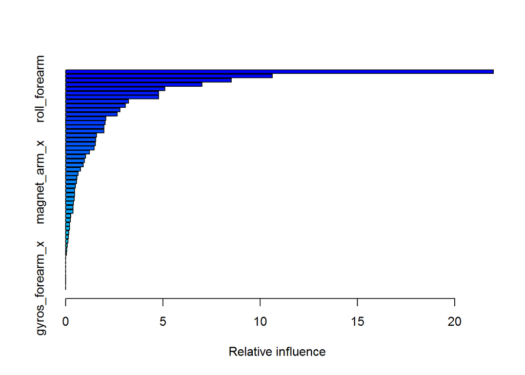

```
##                                 var   rel.inf
## roll_belt                 roll_belt 21.991017
## pitch_forearm         pitch_forearm 10.636149
## yaw_belt                   yaw_belt  8.527107
## magnet_dumbbell_z magnet_dumbbell_z  7.014260
## roll_forearm           roll_forearm  5.102317
## magnet_dumbbell_y magnet_dumbbell_y  4.774342
## magnet_belt_z         magnet_belt_z  4.773396
## gyros_belt_z           gyros_belt_z  3.245112
## roll_dumbbell         roll_dumbbell  3.070139
## pitch_belt               pitch_belt  2.803552
## accel_forearm_x     accel_forearm_x  2.644609
## magnet_forearm_z   magnet_forearm_z  2.065198
## accel_dumbbell_y   accel_dumbbell_y  2.025070
## gyros_dumbbell_y   gyros_dumbbell_y  1.977367
## accel_dumbbell_x   accel_dumbbell_x  1.974208
## magnet_arm_z           magnet_arm_z  1.580579
```

```r
head(summary(gbModel$finalModel),16)
```

## Prediction of the *testing* dataset with the random forest model

The prediction of the *testing* dataset is shown below

```r
testingPred <- predict(rfModel,testing,type="class")
testingPred
```

```
##  1  2  3  4  5  6  7  8  9 10 11 12 13 14 15 16 17 18 19 20
##  B  A  B  A  A  E  D  B  A  A  B  C  B  A  E  E  A  B  B  B
## Levels: A B C D E
```

## Reference

Velloso, E.; Bulling, A.; Gellersen, H.; Ugulino, W.; Fuks, H. Qualitative Activity Recognition of Weight Lifting Exercises. Proceedings of 4th International Conference in Cooperation with SIGCHI (Augmented Human ’13) . Stuttgart, Germany: ACM SIGCHI, 2013.(http://groupware.les.inf.puc-rio.br/har)